# Tugas 4 MPDW

G1401211038_Dhiya Khalishah Tsany Suwarso

2023-09-21

1a.) Bangkitkan model MA(2) dengan
$$\theta_{1}=0.4$$
dan
$$\theta_{2}=0.6$$
sebanyak 300 data (Manual dan dengan arima.sim)

## White Noise

Pembangkitan data berpola AR, MA, ARMA, dan banyak proses deret waktu lainnya diawali pembangkitan *white noise*. *White noise* merupakan sederet nilai dari peubah bebas stokastik identik. Oleh karena itu, *white noise* memiliki dua karakteristik penting:

1. *White noise* tidak memiliki autokorelasi (**karena saling bebas**)
2. Nilai harapan dan ragam *white noise* sama (**karena berasal dari peubah acak bebas stokastik identik**)

*White noise* dibangkitkan dari suatu peubah acak, umumnya peubah acak normal.

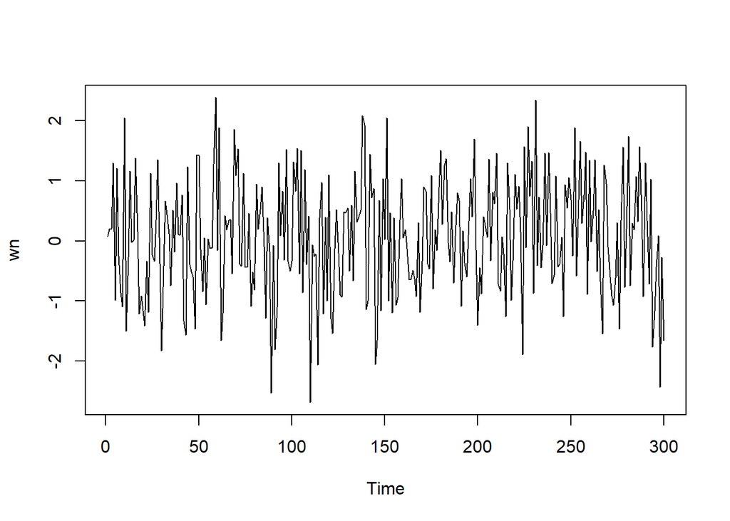

```r
wn <- rnorm(300)
ts.plot(wn)
```

Dapat terlihat bahwa *white noise* tidak memiliki autokorelasi dari ACF. Perhatikan bahwa lag ke-0 adalah korelasi observasi ke-t dengan dirinya sendiri. Nilai korelasi tersebut pasti 1. Sebagai alternatif, lag pertama di plot ACF dapat ditetapkan sebagai 1 (alih-alih 0) dengan menambahkan argumen `xlim(1, lag akhir)`. Plot tersebut dapat disandingkan bersamaan dengan membuat matriks $1 \times 2$ dengan `par(mfrow = c(1,2))`.

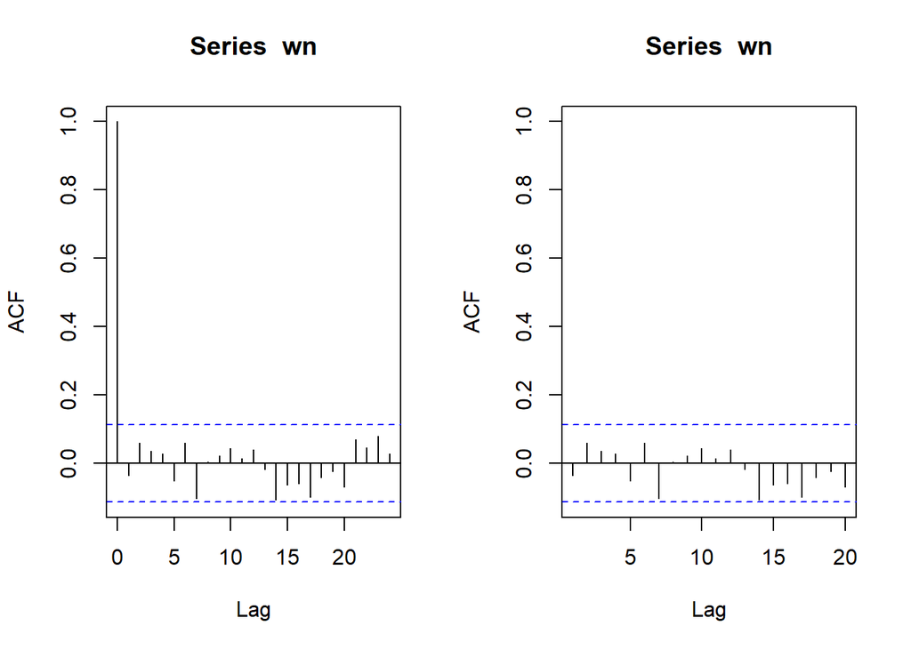

```r
par(mfrow = c(1, 2))
acf(wn)
acf(wn, xlim = c(1, 20))
```

## Proses MA

Proses MA dapat dituliskan sebagai berikut:

$$y_{t} = c + e_t + \theta_{1}e_{t-1} + \theta_{2}e_{t-2} + \dots +
\theta_{q}e_{t-q} = c+{e_t+\sum_{i=1}^p \theta_ie_{t-i}}$$
Terlihat bahwa $e_t$, atau *white noise*, berperan penting dalam pembangkitan proses MA.

## Pembangkitan Proses MA(2)

Akan dicoba membangkitkan proses MA, yaitu MA(2) dengan $\theta_1 = 0.4$ dan $\theta_2 = 0.6$ sebanyak 300 observasi dan $c=0$. Karena diperlukan dua nilai awal untuk $e_{t-1}$ dan $e_{t-2}$, masukkan nilai pertama dan kedua white noise sebagai nilai awal tersebut.

```r
set.seed(1038)
ma <- wn[1]
ma[1] <- wn[1]
ma[2] <- wn[2]
```

Nilai-nilai selanjutnya dapat dicari melalui *loop*. Bentuk loop dapat dilihat dari rumus MA(2) yang hendak dibangkitkan:

$$Y_t = e_t+04e_{t-1}+0.6e_{t-2}$$

```r
set.seed(1038)
for(i in 3:300){
   ma[i] <- wn[i] + 0.4 * wn[i - 1] + 0.6 * wn[i - 2]
}
ma
```

```
##   [1]  0.0736440275  0.1949919654  0.3257060430  1.4928248512 -0.3487119232
##   [6]  1.5905899755 -0.3542621612 -0.2313310509 -1.5907983490  1.0850087834
##  [11] -1.3456456362  0.3510879545  0.1512655078  0.2777980423  0.7000062934
##  [16]  1.3629913588  0.7186837181 -0.3255518279 -1.3015471308 -2.2552941738
##  [21] -2.4259570694 -1.5968221320 -2.1707509715  0.4431935403 -0.4981335412
##  [26]  0.2366277125  0.0697449105  1.2805521192  0.3680733932 -1.1703221567
##  [31] -1.3728857093 -0.5980228200  0.4541497336  0.6924404337 -0.4331918402
##  [36]  0.2801106723 -0.4318306285  1.1904753343  0.3817842003  0.7120626455
##  [41]  0.8637509136 -0.9693666175 -1.6369344562 -0.1896684635 -0.8407903981
##  [46]  0.0720949069 -1.0448145017 -2.0132719284  0.4814579031  1.1141241138
##  [51]  1.2912975436 -0.0424847186 -0.3691085685 -1.5414942663 -0.3598901568
##  [56] -0.7388841877 -0.1500805711  1.1603682371  2.8219683117  1.5628373896
##  [61]  3.2517702166 -0.9957044191 -0.7369454852 -1.0561844485 -0.3686356443
##  [66]  0.6615995726  0.6054473115 -0.2042868380  1.8542299406  1.5051154385
##  [71]  3.0779957677  0.8775794340  0.3429593360  0.7242064672 -0.2420164201
```

[output cut: 45 more lines]

Selain menggunakan cara di atas, pembangkitan proses MA(2) dapat dilakukan dengan fungsi `arima.sim()` sebagai berikut.

```r
set.seed(1038)
ma2 <- arima.sim(list(order=c(0,0,2), ma=c(0.4,0.6)), n=300)
ma2
```

```
## Time Series:
## Start = 1
## End = 300
## Frequency = 1
##   [1] -0.191244750 -1.185874503  1.157009179 -0.806224176  1.354765069
##   [6] -1.822428719 -0.827159439 -2.206854626  0.354487553 -0.656192367
##  [11] -0.629281792 -2.764609496 -2.032412159  0.236153793  1.828370460
##  [16]  1.800055638  0.672977119  0.979951788 -0.815416675  1.293859354
##  [21] -0.138415363 -0.589914223 -1.581090244 -1.837261709 -2.213578955
##  [26] -0.659849160 -1.692071296 -0.656180411  0.773247526 -0.215173326
##  [31]  1.059508906 -1.114791890  1.818107766 -0.859464832  0.825625708
##  [36]  0.658089995  0.006603605  0.415462413  1.529222112 -0.571175921
##  [41]  2.174033732 -1.985758080  0.163916888 -1.153603999 -0.912718648
##  [46] -0.560862941 -1.195878128 -0.167172945 -1.047579412 -1.399803042
##  [51]  0.358240080 -0.962625612 -0.490347750 -1.454839025 -1.466965504
```

[output cut: 49 more lines]

1b.) Buat plot time series, plot ACF, plot PACF, dan plot EACF. Identifikasi apakah data tersebut stasioner

## Karakteristik MA(2)

### Plot Time Series

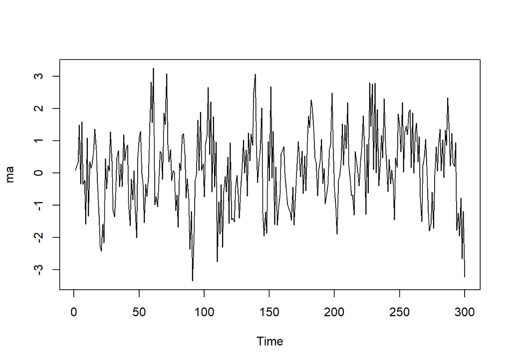

```r
ts.plot(ma)
```

Berdasarkan plot time series, terlihat bahwa data MA(2) yang dibangkitkan stasioner dalam rataan

### Plot ACF

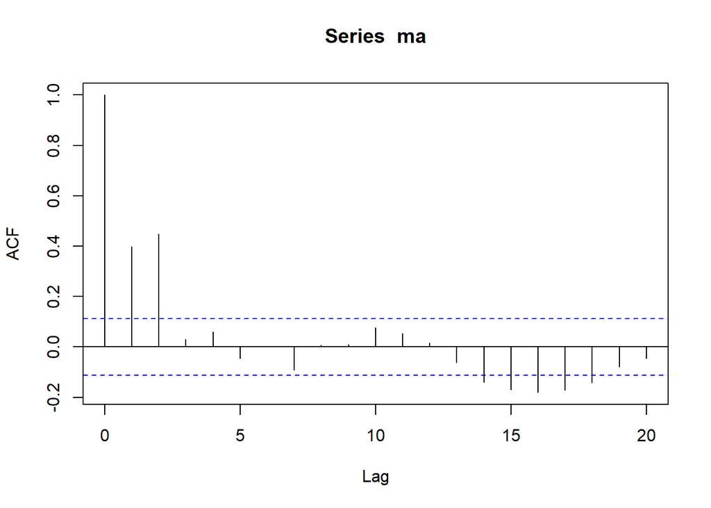

```r
acf(ma,lag.max = 20)
```

Berdasarkan plot AFC tersebut, terlihat bahwa plot ACF *cuts off* di lag kedua

### Plot PACF

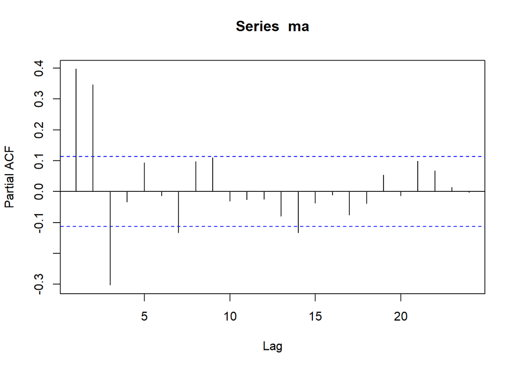

```r
pacf(ma)
```

Berdasarkan plot PACF tersebut, terlihat bahwa plot PACF cenderung *tails off* dan membentuk gelombang sinus

### Plot EACF

```r
TSA::eacf(ma)
```

```
## AR/MA
##   0 1 2 3 4 5 6 7 8 9 10 11 12 13
## 0 x x o o o o o o o o o  o  o  x
## 1 x x x o o o o o o o o  o  o  o
## 2 x x x o o o o o o o o  o  o  o
## 3 o x o o x o o o o o o  o  o  o
## 4 x x o x x o o o o o o  o  o  o
## 5 o x o o x o x o o o o  o  o  o
## 6 o x o o x o o o o o o  o  o  o
## 7 x x o o x o o o o o o  o  o  o
```

Berdasarkan pola segitiga nol pada plot EACF, terlihat bahwa segitiga nol berada pada ordo AR(0) dan ordo MA(2)

3c.) Buat scatterplot antara Yt dengan Yt-1, Yt dengan Yt-2, serta Yt dengan Yt-3

### Scatterplot Antar Lag

#### Korelasi antara $Y_t$ dengan $Y_{t-1}$

```r
#Yt
yt_ma <- ma[-1]
yt_ma
```

```
##   [1]  0.1949919654  0.3257060430  1.4928248512 -0.3487119232  1.5905899755
##   [6] -0.3542621612 -0.2313310509 -1.5907983490  1.0850087834 -1.3456456362
##  [11]  0.3510879545  0.1512655078  0.2777980423  0.7000062934  1.3629913588
##  [16]  0.7186837181 -0.3255518279 -1.3015471308 -2.2552941738 -2.4259570694
##  [21] -1.5968221320 -2.1707509715  0.4431935403 -0.4981335412  0.2366277125
##  [26]  0.0697449105  1.2805521192  0.3680733932 -1.1703221567 -1.3728857093
##  [31] -0.5980228200  0.4541497336  0.6924404337 -0.4331918402  0.2801106723
##  [36] -0.4318306285  1.1904753343  0.3817842003  0.7120626455  0.8637509136
##  [41] -0.9693666175 -1.6369344562 -0.1896684635 -0.8407903981  0.0720949069
##  [46] -1.0448145017 -2.0132719284  0.4814579031  1.1141241138  1.2912975436
##  [51] -0.0424847186 -0.3691085685 -1.5414942663 -0.3598901568 -0.7388841877
##  [56] -0.1500805711  1.1603682371  2.8219683117  1.5628373896  3.2517702166
##  [61] -0.9957044191 -0.7369454852 -1.0561844485 -0.3686356443  0.6615995726
##  [66]  0.6054473115 -0.2042868380  1.8542299406  1.5051154385  3.0779957677
##  [71]  0.8775794340  0.3429593360  0.7242064672 -0.2420164201  0.0646627330
```

[output cut: 45 more lines]

```r
#Yt-1
yt_1_ma <- ma[-300]
yt_1_ma
```

```
##   [1]  0.0736440275  0.1949919654  0.3257060430  1.4928248512 -0.3487119232
##   [6]  1.5905899755 -0.3542621612 -0.2313310509 -1.5907983490  1.0850087834
##  [11] -1.3456456362  0.3510879545  0.1512655078  0.2777980423  0.7000062934
##  [16]  1.3629913588  0.7186837181 -0.3255518279 -1.3015471308 -2.2552941738
##  [21] -2.4259570694 -1.5968221320 -2.1707509715  0.4431935403 -0.4981335412
##  [26]  0.2366277125  0.0697449105  1.2805521192  0.3680733932 -1.1703221567
##  [31] -1.3728857093 -0.5980228200  0.4541497336  0.6924404337 -0.4331918402
##  [36]  0.2801106723 -0.4318306285  1.1904753343  0.3817842003  0.7120626455
##  [41]  0.8637509136 -0.9693666175 -1.6369344562 -0.1896684635 -0.8407903981
##  [46]  0.0720949069 -1.0448145017 -2.0132719284  0.4814579031  1.1141241138
##  [51]  1.2912975436 -0.0424847186 -0.3691085685 -1.5414942663 -0.3598901568
##  [56] -0.7388841877 -0.1500805711  1.1603682371  2.8219683117  1.5628373896
##  [61]  3.2517702166 -0.9957044191 -0.7369454852 -1.0561844485 -0.3686356443
##  [66]  0.6615995726  0.6054473115 -0.2042868380  1.8542299406  1.5051154385
##  [71]  3.0779957677  0.8775794340  0.3429593360  0.7242064672 -0.2420164201
```

[output cut: 45 more lines]

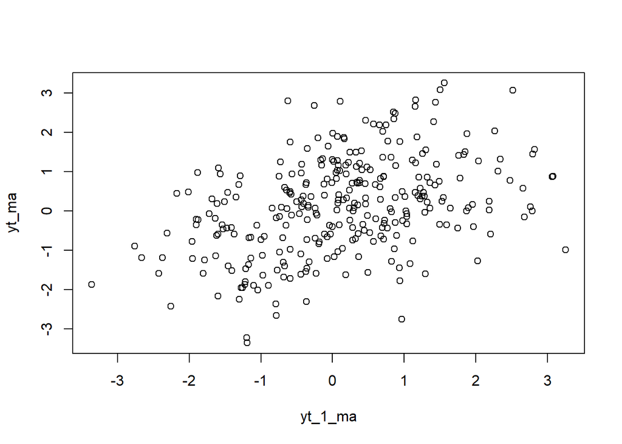

```r
plot(y=yt_ma,x=yt_1_ma)
```

Berdasarkan scatterplot tersebut, terlihat bahwa terdapat hubungan positif antara $Y_t$ dengan $Y_{t-1}$. Hal ini sesuai dengan teori yang ada.

```r
cor(yt_ma,yt_1_ma)
```

```
## [1] 0.4021051
```

Korelasi antara $Y_t$ dengan $Y_{t-1}$ dari hasil simulasi mendekati perhitungan teoritis yaitu

$$\rho_1=\frac{-\theta_1+\theta_1\theta_2}{1+\theta_1^2+\theta_2^2}=\frac{-(-0.4)+(-0.4)(-0.6)}{1+(-0.4)^2+(-0.6)^2}=\frac{8}{19}$$

#### Korelasi antara $Y_t$ dengan $Y_{t-2}$

```r
#Yt
yt_ma2 <- ma[-c(1,2)]
yt_ma2
```

```
##   [1]  0.3257060430  1.4928248512 -0.3487119232  1.5905899755 -0.3542621612
##   [6] -0.2313310509 -1.5907983490  1.0850087834 -1.3456456362  0.3510879545
##  [11]  0.1512655078  0.2777980423  0.7000062934  1.3629913588  0.7186837181
##  [16] -0.3255518279 -1.3015471308 -2.2552941738 -2.4259570694 -1.5968221320
##  [21] -2.1707509715  0.4431935403 -0.4981335412  0.2366277125  0.0697449105
##  [26]  1.2805521192  0.3680733932 -1.1703221567 -1.3728857093 -0.5980228200
##  [31]  0.4541497336  0.6924404337 -0.4331918402  0.2801106723 -0.4318306285
##  [36]  1.1904753343  0.3817842003  0.7120626455  0.8637509136 -0.9693666175
##  [41] -1.6369344562 -0.1896684635 -0.8407903981  0.0720949069 -1.0448145017
##  [46] -2.0132719284  0.4814579031  1.1141241138  1.2912975436 -0.0424847186
##  [51] -0.3691085685 -1.5414942663 -0.3598901568 -0.7388841877 -0.1500805711
##  [56]  1.1603682371  2.8219683117  1.5628373896  3.2517702166 -0.9957044191
##  [61] -0.7369454852 -1.0561844485 -0.3686356443  0.6615995726  0.6054473115
##  [66] -0.2042868380  1.8542299406  1.5051154385  3.0779957677  0.8775794340
##  [71]  0.3429593360  0.7242064672 -0.2420164201  0.0646627330  0.0218925645
```

[output cut: 45 more lines]

```r
#Yt-2
yt_2_ma <- ma[-c(299,300)]
yt_2_ma
```

```
##   [1]  0.0736440275  0.1949919654  0.3257060430  1.4928248512 -0.3487119232
##   [6]  1.5905899755 -0.3542621612 -0.2313310509 -1.5907983490  1.0850087834
##  [11] -1.3456456362  0.3510879545  0.1512655078  0.2777980423  0.7000062934
##  [16]  1.3629913588  0.7186837181 -0.3255518279 -1.3015471308 -2.2552941738
##  [21] -2.4259570694 -1.5968221320 -2.1707509715  0.4431935403 -0.4981335412
##  [26]  0.2366277125  0.0697449105  1.2805521192  0.3680733932 -1.1703221567
##  [31] -1.3728857093 -0.5980228200  0.4541497336  0.6924404337 -0.4331918402
##  [36]  0.2801106723 -0.4318306285  1.1904753343  0.3817842003  0.7120626455
##  [41]  0.8637509136 -0.9693666175 -1.6369344562 -0.1896684635 -0.8407903981
##  [46]  0.0720949069 -1.0448145017 -2.0132719284  0.4814579031  1.1141241138
##  [51]  1.2912975436 -0.0424847186 -0.3691085685 -1.5414942663 -0.3598901568
##  [56] -0.7388841877 -0.1500805711  1.1603682371  2.8219683117  1.5628373896
##  [61]  3.2517702166 -0.9957044191 -0.7369454852 -1.0561844485 -0.3686356443
##  [66]  0.6615995726  0.6054473115 -0.2042868380  1.8542299406  1.5051154385
##  [71]  3.0779957677  0.8775794340  0.3429593360  0.7242064672 -0.2420164201
```

[output cut: 45 more lines]

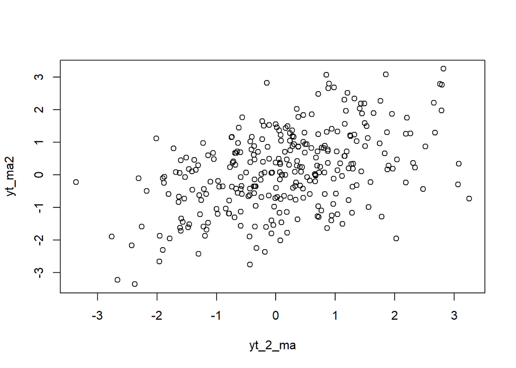

```r
plot(y=yt_ma2,x=yt_2_ma)
```

Berdasarkan scatterplot tersebut, terlihat bahwa cenderung terdapat hubungan positif antara $Y_t$ dengan $Y_{t-2}$.

```r
cor(yt_ma2,yt_2_ma)
```

```
## [1] 0.4557274
```

Korelasi antara $Y_t$ dengan $Y_{t-2}$ dari hasil simulasi mendekati perhitungan teoritis yaitu
$$\rho_2=\frac{-\theta_2}{1+\theta_1^2+\theta_2^2}=\frac{-(-0.6)}{1+(-0.4)^2+(-0.6)^2}=\frac{15}{38}$$

```r
#Yt
yt_ma3 <- ma[-c(1,2,3)]
yt_ma3
```

```
##   [1]  1.4928248512 -0.3487119232  1.5905899755 -0.3542621612 -0.2313310509
##   [6] -1.5907983490  1.0850087834 -1.3456456362  0.3510879545  0.1512655078
##  [11]  0.2777980423  0.7000062934  1.3629913588  0.7186837181 -0.3255518279
##  [16] -1.3015471308 -2.2552941738 -2.4259570694 -1.5968221320 -2.1707509715
##  [21]  0.4431935403 -0.4981335412  0.2366277125  0.0697449105  1.2805521192
##  [26]  0.3680733932 -1.1703221567 -1.3728857093 -0.5980228200  0.4541497336
##  [31]  0.6924404337 -0.4331918402  0.2801106723 -0.4318306285  1.1904753343
##  [36]  0.3817842003  0.7120626455  0.8637509136 -0.9693666175 -1.6369344562
##  [41] -0.1896684635 -0.8407903981  0.0720949069 -1.0448145017 -2.0132719284
##  [46]  0.4814579031  1.1141241138  1.2912975436 -0.0424847186 -0.3691085685
##  [51] -1.5414942663 -0.3598901568 -0.7388841877 -0.1500805711  1.1603682371
##  [56]  2.8219683117  1.5628373896  3.2517702166 -0.9957044191 -0.7369454852
##  [61] -1.0561844485 -0.3686356443  0.6615995726  0.6054473115 -0.2042868380
##  [66]  1.8542299406  1.5051154385  3.0779957677  0.8775794340  0.3429593360
##  [71]  0.7242064672 -0.2420164201  0.0646627330  0.0218925645 -1.1672011007
```

[output cut: 45 more lines]

```r
#Yt-3
yt_3_ma <- ma[-c(298,299,300)]
yt_3_ma
```

```
##   [1]  0.0736440275  0.1949919654  0.3257060430  1.4928248512 -0.3487119232
##   [6]  1.5905899755 -0.3542621612 -0.2313310509 -1.5907983490  1.0850087834
##  [11] -1.3456456362  0.3510879545  0.1512655078  0.2777980423  0.7000062934
##  [16]  1.3629913588  0.7186837181 -0.3255518279 -1.3015471308 -2.2552941738
##  [21] -2.4259570694 -1.5968221320 -2.1707509715  0.4431935403 -0.4981335412
##  [26]  0.2366277125  0.0697449105  1.2805521192  0.3680733932 -1.1703221567
##  [31] -1.3728857093 -0.5980228200  0.4541497336  0.6924404337 -0.4331918402
##  [36]  0.2801106723 -0.4318306285  1.1904753343  0.3817842003  0.7120626455
##  [41]  0.8637509136 -0.9693666175 -1.6369344562 -0.1896684635 -0.8407903981
##  [46]  0.0720949069 -1.0448145017 -2.0132719284  0.4814579031  1.1141241138
##  [51]  1.2912975436 -0.0424847186 -0.3691085685 -1.5414942663 -0.3598901568
##  [56] -0.7388841877 -0.1500805711  1.1603682371  2.8219683117  1.5628373896
##  [61]  3.2517702166 -0.9957044191 -0.7369454852 -1.0561844485 -0.3686356443
##  [66]  0.6615995726  0.6054473115 -0.2042868380  1.8542299406  1.5051154385
##  [71]  3.0779957677  0.8775794340  0.3429593360  0.7242064672 -0.2420164201
```

[output cut: 45 more lines]

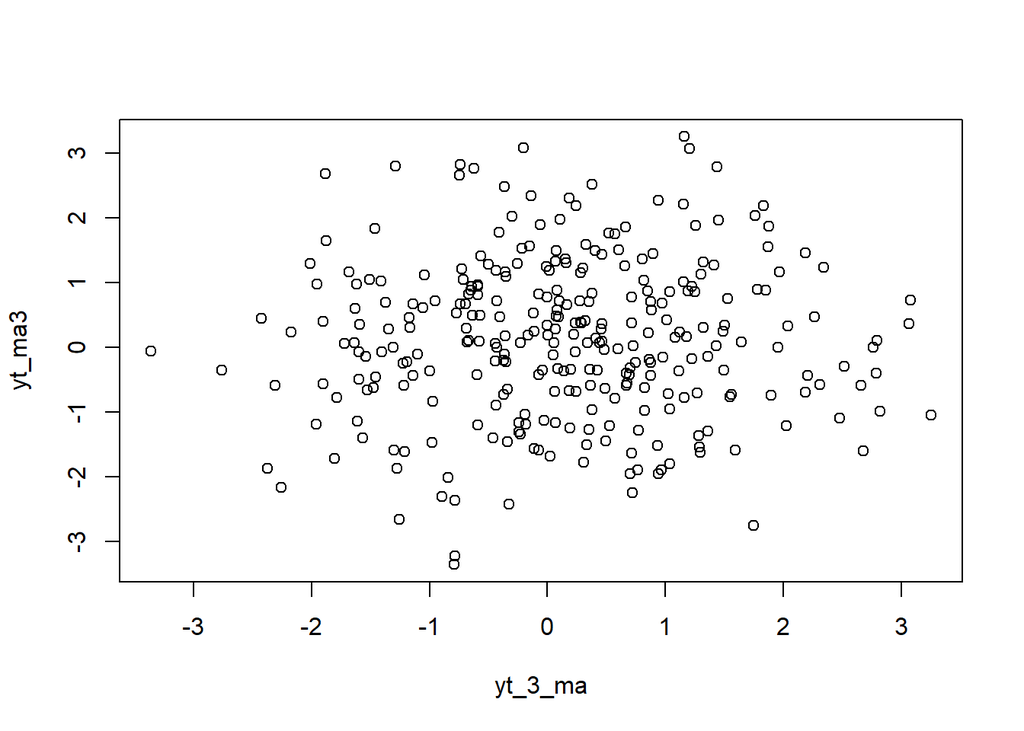

```r
plot(y=yt_ma3,x=yt_3_ma)
```

```r
cor(yt_ma3,yt_3_ma)
```

```
## [1] 0.03016787
```

Korelasi antara Yt dengan Yt−3 hasil simulasi mendekati teori yang ada yaitu 0.

2a.) Bangkitkan model AR(2) dengan
$$\phi_1=0.5$$
dan
$$\phi_2=0.2$$
sebanyak 300 data (Manual dan dengan arima.sim)

## Proses AR

Proses AR dapat dituliskan sebagai berikut:

$$y_{t} = c + e_t + \phi_{1}Y_{t-1} +
\phi_{2}Y_{t-2} + \dots + \phi_{q}Y_{t-q} = c+{e_t+\sum_{i=1}^p
\phi_iY_{t-i}}$$
Terlihat bahwa $Y_t$ berperan penting dalam pembangkitan proses AR.

## Pembangkitan Proses AR

Akan dicoba membangkitkan proses AR, yaitu AR(2) dengan
$$\phi_1=0.5$$
dan
$$\phi_2=0.2$$
sebanyak 300 observasi dan $c=0$.

```r
set.seed(1038)
```

Nilai-nilai selanjutnya dapat dicari melalui *loop*. Bentuk loop dapat dilihat dari rumus AR(2) yang hendak dibangkitkan:

$$Y_t =
e_t+0.5Y_{t-1}+0.2Y_{t-2}$$

```r
set.seed(1038)
n<-length(wn)
n
```

```
## [1] 300
```

```r
ar <- c(1:n)
for (i in 3:n) {ar[i]<-wn[i]+0.5*ar[i-1]+0.2*ar[i-2]}
ar
```

```
##   [1]  1.000000000  2.000000000  1.403522840  2.396181956  0.490201704
##   [6]  1.933712434  0.820040625 -0.062250993 -0.967396644  1.544380247
##  [11] -0.922978785 -0.425166817  0.764121480  0.273837245  0.302244877
##  [16]  1.577794542  1.011766928 -0.392220521 -0.907291257 -1.693772418
##  [21] -2.441507826 -1.894055571 -2.624363433 -0.571457353 -1.043128646
##  [26] -0.977938455 -0.351500612  0.976025981  0.039184063 -1.612531794
##  [31] -1.213265902 -0.264829990  0.062259921  0.097087566 -0.682162372
##  [36]  0.184356093 -0.232598079  0.882773114  0.504776958  0.519721180
##  [41]  1.122309654 -0.663331870 -1.669662291  0.264875891 -0.597759303
##  [46] -0.754727697 -1.100442047 -2.167734022  0.126245269  1.051560144
##  [51]  0.415412530 -0.423410375 -0.079789825 -1.180747195 -0.573053350
##  [56] -0.641169462 -0.557845560  0.873367637  2.708463390  1.370088553
##  [61]  3.112024629  0.175500538 -0.496151100  0.206080319  0.191335768
##  [66]  0.472039732  0.633156520 -0.137941902  1.916139837  2.021562048
##  [71]  2.920484865  1.476895620  0.904682284  1.871667266  0.675892369
```

[output cut: 45 more lines]

Selain menggunakan cara di atas, pembangkitan proses AR dapat dilakukan dengan fungsi `arima.sim()` sebagai berikut.

```r
set.seed(1038)
ar1 <- arima.sim(list(order=c(2,0,0), ar=c(0.5,0.2)), n=300)
ar1
```

```
## Time Series:
## Start = 1
## End = 300
## Frequency = 1
##   [1] -1.47214342 -2.31230107 -1.20749858 -2.07371069 -1.67738338  0.28392574
##   [7] -0.78421397  0.03805139 -1.04753818  1.44181345 -0.58542200  0.08522248
##  [13]  1.20588117  0.06070448  0.14249053  1.99979181 -0.23192140  1.81231417
##  [19] -0.98112263 -0.14481332 -0.31101199 -1.07020608 -0.77844493 -1.19524356
##  [25] -0.57500806 -1.29026531 -1.96143390  0.05821746 -1.12381887 -1.51454985
##  [31] -1.59477967 -1.74359858 -1.64633262 -2.56157221 -2.03677983 -1.04135015
##  [37] -0.03260880 -2.86470486 -0.85711378 -2.02734905 -2.33787514 -1.70793414
##  [43] -1.01988853 -2.47051869 -2.23432392 -1.47126547 -1.18307128  1.36976556
##  [49]  1.33141678  0.70136869 -0.26971383  0.54496655 -0.15039488 -0.39671778
##  [55]  0.04986182 -0.67380229 -0.70957897 -1.36089042 -1.51539422  0.03727346
##  [61] -0.59070533 -1.14401199 -0.58788066 -0.23932926 -1.42965509 -0.20518158
```

[output cut: 39 more lines]

2b.) Buat plot time series, plot ACF, plot PACF, dan plot EACF. Identifikasi apakah data tersebut stasioner

## Karakteristik AR(2)

### Plot Time Series

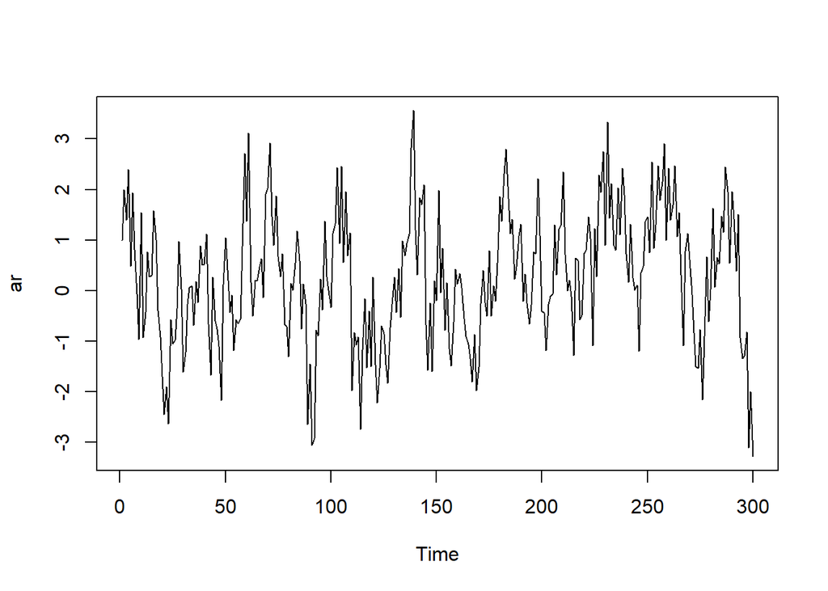

```r
ts.plot(ar)
```

Berdasarkan plot time series tersebut terlihat bahwa data cenderung stasioner pada rataan

### Plot ACF

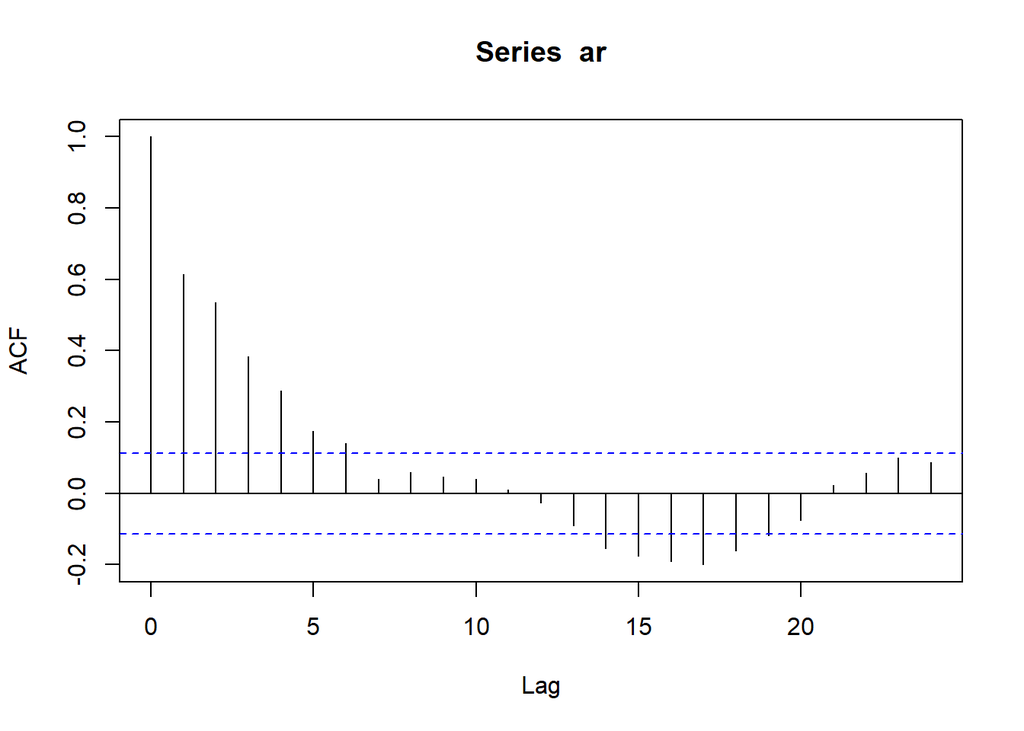

```r
acf(ar)
```

Berdasarkan plot ACF tersebut terlihat bahwa plot ACF cenderung *tails off* dan cenderung membentuk pola grafik sinus

### Plot PACF

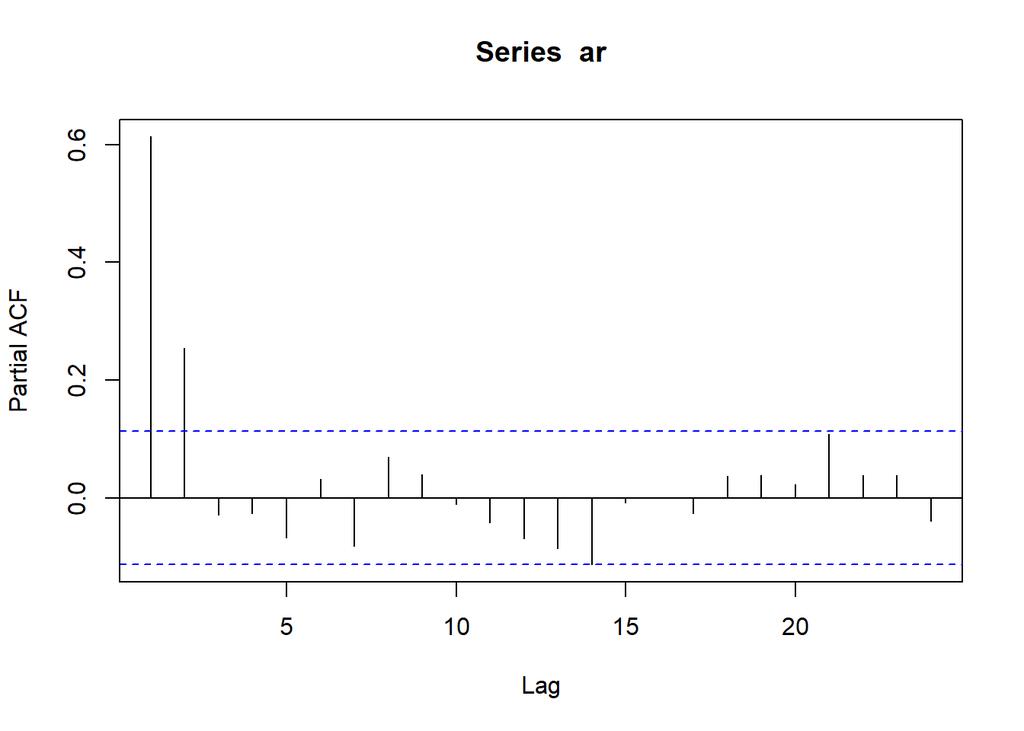

```r
pacf(ar)
```

Berdasarkan plot PACF tersebut, terlihat bahwa plot PACF *cuts off* pada lag kedua, sejalan dengan teori yang ada

### Plot EACF

```r
TSA::eacf(ar)
```

```
## AR/MA
##   0 1 2 3 4 5 6 7 8 9 10 11 12 13
## 0 x x x x x x o o o o o  o  o  x
## 1 x x o o o x x o o o o  o  o  o
## 2 o o o o o o o o o o o  o  o  o
## 3 x o x o o o o o o o o  o  o  o
## 4 x o x o o o o o o o o  o  o  o
## 5 x x x o o o o o o o o  o  o  o
## 6 x x x x x o o o o o o  o  o  o
## 7 x x x o x x o o o o o  o  o  o
```

Berdasarkan pola segitiga nol pada plot EACF, terlihat bahwa segitiga nol berada pada ordo AR(2) dan ordo MA(0)

3c.) Buat scatterplot antara Yt dengan Yt-1, Yt dengan Yt-2, serta Yt dengan Yt-3

### Scatterplot Antar Lag

#### Korelasi antara $Y_t$ dengan $Y_{t-1}$

```r
#Yt
yt_ar <- ar[-1]
yt_ar
```

```
##   [1]  2.000000000  1.403522840  2.396181956  0.490201704  1.933712434
##   [6]  0.820040625 -0.062250993 -0.967396644  1.544380247 -0.922978785
##  [11] -0.425166817  0.764121480  0.273837245  0.302244877  1.577794542
##  [16]  1.011766928 -0.392220521 -0.907291257 -1.693772418 -2.441507826
##  [21] -1.894055571 -2.624363433 -0.571457353 -1.043128646 -0.977938455
##  [26] -0.351500612  0.976025981  0.039184063 -1.612531794 -1.213265902
##  [31] -0.264829990  0.062259921  0.097087566 -0.682162372  0.184356093
##  [36] -0.232598079  0.882773114  0.504776958  0.519721180  1.122309654
##  [41] -0.663331870 -1.669662291  0.264875891 -0.597759303 -0.754727697
##  [46] -1.100442047 -2.167734022  0.126245269  1.051560144  0.415412530
##  [51] -0.423410375 -0.079789825 -1.180747195 -0.573053350 -0.641169462
##  [56] -0.557845560  0.873367637  2.708463390  1.370088553  3.112024629
##  [61]  0.175500538 -0.496151100  0.206080319  0.191335768  0.472039732
##  [66]  0.633156520 -0.137941902  1.916139837  2.021562048  2.920484865
##  [71]  1.476895620  0.904682284  1.871667266  0.675892369  0.278925259
```

[output cut: 45 more lines]

```r
#Yt-1
yt_1_ar <- ar[-300]
yt_1_ar
```

```
##   [1]  1.000000000  2.000000000  1.403522840  2.396181956  0.490201704
##   [6]  1.933712434  0.820040625 -0.062250993 -0.967396644  1.544380247
##  [11] -0.922978785 -0.425166817  0.764121480  0.273837245  0.302244877
##  [16]  1.577794542  1.011766928 -0.392220521 -0.907291257 -1.693772418
##  [21] -2.441507826 -1.894055571 -2.624363433 -0.571457353 -1.043128646
##  [26] -0.977938455 -0.351500612  0.976025981  0.039184063 -1.612531794
##  [31] -1.213265902 -0.264829990  0.062259921  0.097087566 -0.682162372
##  [36]  0.184356093 -0.232598079  0.882773114  0.504776958  0.519721180
##  [41]  1.122309654 -0.663331870 -1.669662291  0.264875891 -0.597759303
##  [46] -0.754727697 -1.100442047 -2.167734022  0.126245269  1.051560144
##  [51]  0.415412530 -0.423410375 -0.079789825 -1.180747195 -0.573053350
##  [56] -0.641169462 -0.557845560  0.873367637  2.708463390  1.370088553
##  [61]  3.112024629  0.175500538 -0.496151100  0.206080319  0.191335768
##  [66]  0.472039732  0.633156520 -0.137941902  1.916139837  2.021562048
##  [71]  2.920484865  1.476895620  0.904682284  1.871667266  0.675892369
```

[output cut: 45 more lines]

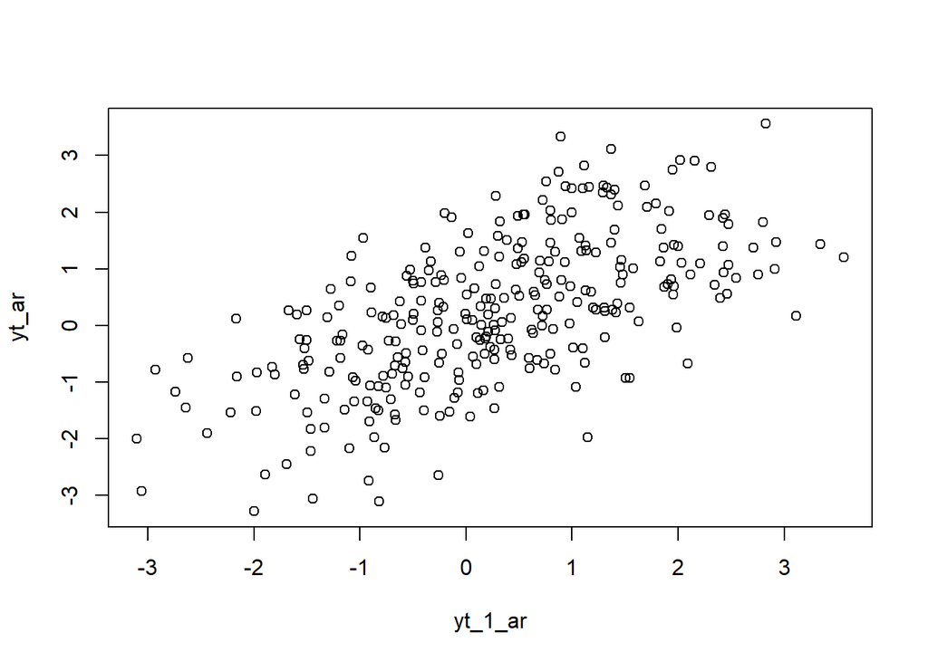

```r
plot(y=yt_ar,x=yt_1_ar)
```

Berdasarkan scatterplot tersebut, terlihat bahwa terdapat hubungan positif antara $Y_t$ dengan $Y_{t-1}$. Hal ini sesuai dengan teori yang ada

```r
cor(yt_ar,yt_1_ar)
```

```
## [1] 0.6214474
```

Korelasi antara $Y_t$ dengan $Y_{t-1}$ dari hasil simulasi mendekati perhitungan teoritis yaitu
$$\rho_1 =
\frac{\phi_1}{1-\phi_2}=0.625$$

#### Korelasi antara $Y_t$ dengan $Y_{t-2}$

```r
#Yt
yt_ar2 <- ar[-c(1,2)]
yt_ar2
```

```
##   [1]  1.403522840  2.396181956  0.490201704  1.933712434  0.820040625
##   [6] -0.062250993 -0.967396644  1.544380247 -0.922978785 -0.425166817
##  [11]  0.764121480  0.273837245  0.302244877  1.577794542  1.011766928
##  [16] -0.392220521 -0.907291257 -1.693772418 -2.441507826 -1.894055571
##  [21] -2.624363433 -0.571457353 -1.043128646 -0.977938455 -0.351500612
##  [26]  0.976025981  0.039184063 -1.612531794 -1.213265902 -0.264829990
##  [31]  0.062259921  0.097087566 -0.682162372  0.184356093 -0.232598079
##  [36]  0.882773114  0.504776958  0.519721180  1.122309654 -0.663331870
##  [41] -1.669662291  0.264875891 -0.597759303 -0.754727697 -1.100442047
##  [46] -2.167734022  0.126245269  1.051560144  0.415412530 -0.423410375
##  [51] -0.079789825 -1.180747195 -0.573053350 -0.641169462 -0.557845560
##  [56]  0.873367637  2.708463390  1.370088553  3.112024629  0.175500538
##  [61] -0.496151100  0.206080319  0.191335768  0.472039732  0.633156520
##  [66] -0.137941902  1.916139837  2.021562048  2.920484865  1.476895620
##  [71]  0.904682284  1.871667266  0.675892369  0.278925259  0.734402052
```

[output cut: 45 more lines]

```r
#Yt-2
yt_2_ar <- ar[-c(299,300)]
yt_2_ar
```

```
##   [1]  1.000000000  2.000000000  1.403522840  2.396181956  0.490201704
##   [6]  1.933712434  0.820040625 -0.062250993 -0.967396644  1.544380247
##  [11] -0.922978785 -0.425166817  0.764121480  0.273837245  0.302244877
##  [16]  1.577794542  1.011766928 -0.392220521 -0.907291257 -1.693772418
##  [21] -2.441507826 -1.894055571 -2.624363433 -0.571457353 -1.043128646
##  [26] -0.977938455 -0.351500612  0.976025981  0.039184063 -1.612531794
##  [31] -1.213265902 -0.264829990  0.062259921  0.097087566 -0.682162372
##  [36]  0.184356093 -0.232598079  0.882773114  0.504776958  0.519721180
##  [41]  1.122309654 -0.663331870 -1.669662291  0.264875891 -0.597759303
##  [46] -0.754727697 -1.100442047 -2.167734022  0.126245269  1.051560144
##  [51]  0.415412530 -0.423410375 -0.079789825 -1.180747195 -0.573053350
##  [56] -0.641169462 -0.557845560  0.873367637  2.708463390  1.370088553
##  [61]  3.112024629  0.175500538 -0.496151100  0.206080319  0.191335768
##  [66]  0.472039732  0.633156520 -0.137941902  1.916139837  2.021562048
##  [71]  2.920484865  1.476895620  0.904682284  1.871667266  0.675892369
```

[output cut: 45 more lines]

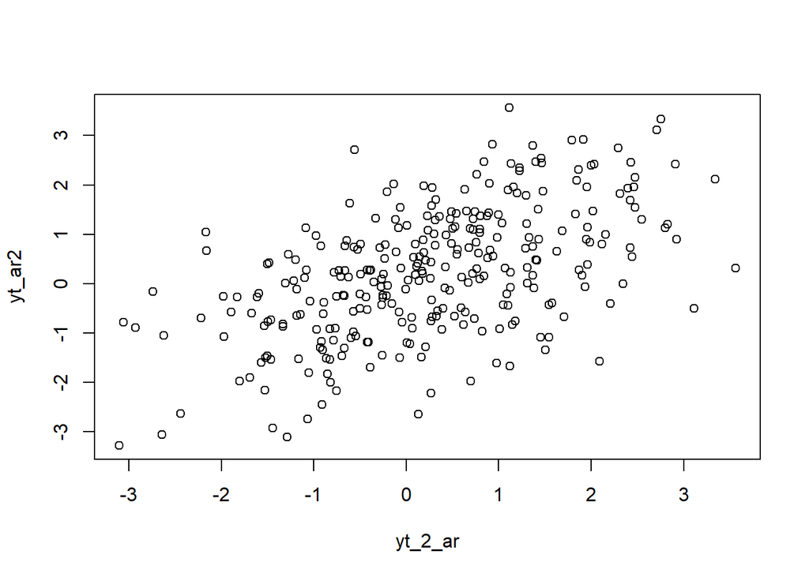

```r
plot(y=yt_ar2,x=yt_2_ar)
```

Berdasarkan scatterplot tersebut, terlihat bahwa terdapat hubungan positif antara $Y_t$ dengan $Y_{t-2}$. Hal ini sesuai dengan teori yang ada

```r
cor(yt_ar2,yt_2_ar)
```

```
## [1] 0.5465984
```

Korelasi antara $Y_t$ dengan $Y_{t-2}$ dari hasil simulasi mendekati perhitungan teoritis yaitu $\rho_2=\phi_1\rho_1+\phi_2\rho_0=0.5125$.

#### Korelasi antara $Y_t$ dengan $Y_{t-3}$

```r
#Yt
yt_ar3 <- ar[-c(1,2,3)]
yt_ar3
```

```
##   [1]  2.396181956  0.490201704  1.933712434  0.820040625 -0.062250993
##   [6] -0.967396644  1.544380247 -0.922978785 -0.425166817  0.764121480
##  [11]  0.273837245  0.302244877  1.577794542  1.011766928 -0.392220521
##  [16] -0.907291257 -1.693772418 -2.441507826 -1.894055571 -2.624363433
##  [21] -0.571457353 -1.043128646 -0.977938455 -0.351500612  0.976025981
##  [26]  0.039184063 -1.612531794 -1.213265902 -0.264829990  0.062259921
##  [31]  0.097087566 -0.682162372  0.184356093 -0.232598079  0.882773114
##  [36]  0.504776958  0.519721180  1.122309654 -0.663331870 -1.669662291
##  [41]  0.264875891 -0.597759303 -0.754727697 -1.100442047 -2.167734022
##  [46]  0.126245269  1.051560144  0.415412530 -0.423410375 -0.079789825
##  [51] -1.180747195 -0.573053350 -0.641169462 -0.557845560  0.873367637
##  [56]  2.708463390  1.370088553  3.112024629  0.175500538 -0.496151100
##  [61]  0.206080319  0.191335768  0.472039732  0.633156520 -0.137941902
##  [66]  1.916139837  2.021562048  2.920484865  1.476895620  0.904682284
##  [71]  1.871667266  0.675892369  0.278925259  0.734402052 -0.668106775
```

[output cut: 45 more lines]

```r
#Yt-3
yt_3_ar <- ar[-c(298,299,300)]
yt_3_ar
```

```
##   [1]  1.000000000  2.000000000  1.403522840  2.396181956  0.490201704
##   [6]  1.933712434  0.820040625 -0.062250993 -0.967396644  1.544380247
##  [11] -0.922978785 -0.425166817  0.764121480  0.273837245  0.302244877
##  [16]  1.577794542  1.011766928 -0.392220521 -0.907291257 -1.693772418
##  [21] -2.441507826 -1.894055571 -2.624363433 -0.571457353 -1.043128646
##  [26] -0.977938455 -0.351500612  0.976025981  0.039184063 -1.612531794
##  [31] -1.213265902 -0.264829990  0.062259921  0.097087566 -0.682162372
##  [36]  0.184356093 -0.232598079  0.882773114  0.504776958  0.519721180
##  [41]  1.122309654 -0.663331870 -1.669662291  0.264875891 -0.597759303
##  [46] -0.754727697 -1.100442047 -2.167734022  0.126245269  1.051560144
##  [51]  0.415412530 -0.423410375 -0.079789825 -1.180747195 -0.573053350
##  [56] -0.641169462 -0.557845560  0.873367637  2.708463390  1.370088553
##  [61]  3.112024629  0.175500538 -0.496151100  0.206080319  0.191335768
##  [66]  0.472039732  0.633156520 -0.137941902  1.916139837  2.021562048
##  [71]  2.920484865  1.476895620  0.904682284  1.871667266  0.675892369
```

[output cut: 45 more lines]

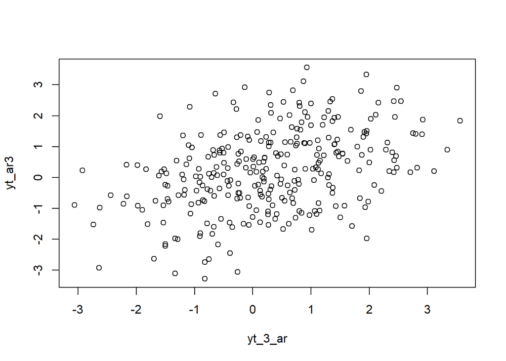

```r
plot(y=yt_ar3,x=yt_3_ar)
```

Berdasarkan scatterplot tersebut, terlihat bahwa terdapat hubungan positif antara $Y_t$ dengan $Y_{t-3}$. Hal ini sesuai dengan teori yang ada

```r
cor(yt_ar3,yt_3_ar)
```

```
## [1] 0.3976849
```

Korelasi antara $Y_t$ dengan $Y_{t-3}$ dari hasil simulasi mendekati perhitungan teoritis yaitu $\rho_3=\phi_1\rho_2+\phi_2\rho_1=0.38125$.

3a.) Bangkitkan model ARMA(2,2) dengan
$$\theta_1 = 0.4$$
,
$$\theta_2 = 0.6$$
,
$$\phi_1 = 0.5$$
, dan
$$\phi_2 = 0.2$$
sebanyak 300 data (Manual dan arima.sim)

## Fungsi pembangkitan ARMA

Bentuk umum data berpola ARMA adalah sebagai berikut.

$$y_{t} = c + \sum_{i=1}^p \phi_{i}y_{t-i} + \sum_{j=1}^q e_{t-j}+ e_{t}$$

Maka dari itu,

$$\begin{aligned}
\begin{bmatrix}
\phi_1 \ \phi_2
\end{bmatrix}
\begin{bmatrix}
y_{t-1} \\ y_{t-2} \
\end{bmatrix} &= \phi_1 \ y_{t-1}+\phi_2 \ y_{t-2}
\\
\begin{bmatrix}
0.4 \ 0.6
\end{bmatrix}
\begin{bmatrix}
0.5 \\ 0.2
\end{bmatrix} & = 0.4 \cdot0.5+0.6 \cdot 0.2\\
&=0.2+0.12 = 0.32
\end{aligned}$$

Jika koefisien dan *white noise*/nilai deret waktu sebelumnya dapat diekstrak dalam bentuk vektor, dapat dilakukan perkalian matriks untuk mencari nilai bagian AR dan MA:

```r
set.seed(1038)
coefs <- c(0.4, 0.6)
e <- c(0.5, 0.2)

coefs %*% e
```

```
##      [,1]
## [1,] 0.32
```

Atau, dapat dilakukan perkalian *elementwise* yang dijumlahkan:

```r
coefs * e
```

```
## [1] 0.20 0.12
```

```r
sum(coefs * e)
```

```
## [1] 0.32
```

Dari prinsip ini, dapat dibuat fungsi umum untuk membangkitkan data ARMA. Input dari fungsi adalah jumlah data yang hendak dibangkitkan, koefisien MA, dan koefisien AR

```r
arma.sim <- function(n, macoef, arcoef){
  manum <- length(macoef)
  arnum <- length(arcoef)
  stopifnot(manum < n & arnum < n)

  wn <- rnorm(n, sd = 0.5)
  init <- max(manum, arnum)

  arma <- wn[1:init]
  for(i in {init+1}:n){
   mastart <- i - manum
   maend <- i-1
   arstart <- i - arnum
   arend <- i-1
   arma[i] <- sum(arcoef * arma[arstart:arend]) + sum(macoef * wn[mastart:maend])  + wn[i]
   }
  return(arma)
}
```

```r
set.seed(1038)
n = length(wn)
phi1 = 0.5
phi2 = 0.2
theta1 = 0.4
theta2 = 0.6

y.arma=c(1:n)
for (i in 3:n){y.arma[i] = phi1*y.arma[i-1] +phi2*y.arma[i-2]+theta1*wn[i-1]+theta2*wn[i-2]+wn[i]}
y.arma
```

```
##   [1]  1.000000e+00  2.000000e+00  1.525706e+00  2.655678e+00  1.284268e+00
##   [6]  2.763860e+00  1.284521e+00  9.637015e-01 -8.520433e-01  8.517274e-01
##  [11] -1.090191e+00 -2.366185e-02 -7.860353e-02  2.337639e-01  8.011675e-01
##  [16]  1.810328e+00  1.784081e+00  9.285543e-01 -4.804537e-01 -2.309810e+00
##  [21] -3.676953e+00 -3.897261e+00 -4.854772e+00 -2.763645e+00 -2.850910e+00
##  [26] -1.741556e+00 -1.371215e+00  2.466332e-01  2.171470e-01 -1.012422e+00
##  [31] -1.835667e+00 -1.718341e+00 -7.721542e-01 -3.730483e-02 -6.062751e-01
##  [36] -3.048784e-02 -5.683296e-01  9.002130e-01  7.182248e-01  1.251218e+00
##  [41]  1.633005e+00  9.737925e-02 -1.261644e+00 -8.010146e-01 -1.493626e+00
##  [46] -8.349212e-01 -1.761000e+00 -3.060756e+00 -1.401120e+00 -1.985873e-01
##  [51]  9.117798e-01  3.736877e-01  9.124596e-05 -1.466711e+00 -1.093227e+00
##  [56] -1.578840e+00 -1.158146e+00  2.655271e-01  2.723103e+00  2.977494e+00
##  [61]  5.285138e+00  2.242363e+00  1.441264e+00  1.129201e-01 -2.392285e-02
##  [66]  6.722222e-01  9.367738e-01  3.985445e-01  2.240857e+00  2.705253e+00
##  [71]  4.878794e+00  3.858027e+00  3.247731e+00  3.119678e+00  1.967369e+00
```

[output cut: 45 more lines]

Pembangkitan ARMA(p,q) juga dapat dilakukan dengan fungsi `arima.sim` sebagai berikut.

```r
arma11 <- arima.sim(list(order=c(2,0,2), ar = c(0.5,0.2), ma = c(0.4,0.6)), n=300)
arma11
```

```
## Time Series:
## Start = 1
## End = 300
## Frequency = 1
##   [1] -3.015431801 -3.943882443 -3.231207993 -1.631132959 -1.676981403
##   [6] -0.105208387 -1.502792365  1.045669906 -0.637188352  0.716165513
##  [11]  0.888735081  0.594204249  0.890311553  2.093218738  0.653495759
##  [16]  2.919425359 -0.395346248  0.550128836 -0.957608831 -1.281497296
##  [21] -1.393133355 -2.148744265 -1.520171748 -2.237414139 -2.822544461
##  [26] -1.500514978 -2.277391994 -1.929146743 -2.874890795 -3.290240250
##  [31] -3.300639770 -4.266264344 -4.049208237 -3.393005373 -1.671216730
##  [36] -3.502558447 -2.022560989 -4.089017462 -3.663083018 -3.859493620
##  [41] -3.105787264 -3.903234581 -3.834464514 -3.847306249 -3.112171825
##  [46]  0.013777764  1.169480232  2.055794736  0.809683713  0.857902234
##  [51] -0.094236558 -0.129895804 -0.199062221 -0.891888227 -0.949182787
```

[output cut: 49 more lines]

3b.) Buat plot time series, plot ACF, plot PACF, dan plot EACF. Identifikasi apakah data tersebut stasioner

## Karakteristik ARMA(2,2)

### Plot Time Series

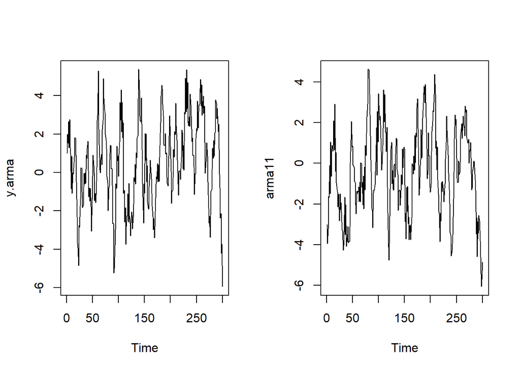

```r
par(mfrow = c(1, 2))
ts.plot(y.arma)
ts.plot(arma11)
```

```r
par(mfrow = c(1, 1))
```

Berdasarkan plot time series tersebut, terlihat bahwa model ARMA(2,2) cenderung stasioner dalam rataan

### Plot ACF

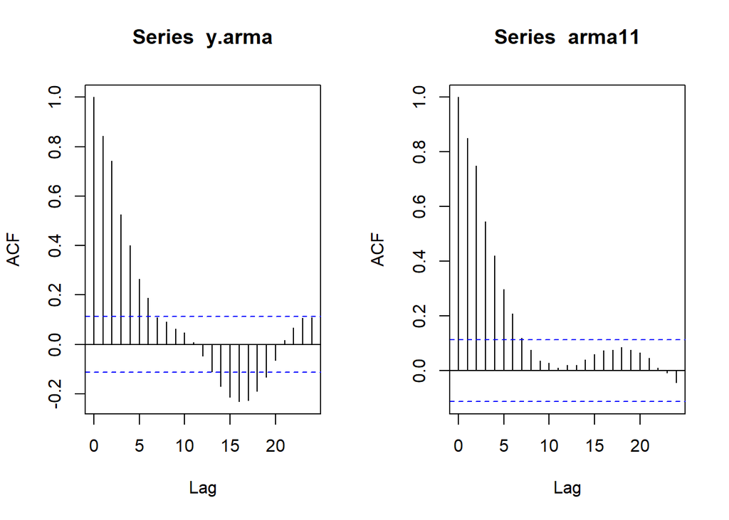

```r
par(mfrow = c(1, 2))
acf(y.arma)
acf(arma11)
```

```r
par(mfrow = c(1, 1))
```

Berdasarkan plot ACF tersebut, terlihat bahwa model ARMA(2,2) hasil simulasi memiliki plot ACF yang *tails off*, sesuai dengan teori yang ada

### Plot PACF

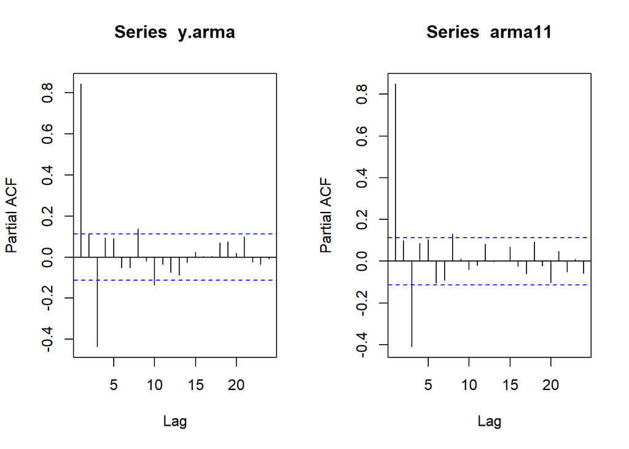

```r
par(mfrow = c(1, 2))
pacf(y.arma)
pacf(arma11)
```

```r
par(mfrow = c(1, 1))
```

Berdasarkan plot PACF tersebut, terlihat bahwa model ARMA(2,2) hasil simulasi memiliki plot PACF yang *tails off*, sesuai dengan teori

### Plot EACF

```r
TSA::eacf(y.arma)
```

```
## AR/MA
##   0 1 2 3 4 5 6 7 8 9 10 11 12 13
## 0 x x x x x x o o o o o  o  o  x
## 1 x x x x o o x o o o o  o  o  o
## 2 x x x o o o o o o o o  o  o  o
## 3 x x o x o o o o o o o  o  o  o
## 4 x x o o x o o o o o o  o  o  o
## 5 x x o o o x o o o o o  o  o  o
## 6 x x o o o o x o o o o  o  o  o
## 7 x x x o o o x o o o o  o  o  o
```

```r
TSA::eacf(arma11)
```

```
## AR/MA
##   0 1 2 3 4 5 6 7 8 9 10 11 12 13
## 0 x x x x x x x o o o o  o  o  o
## 1 x x x x o o o o o o o  o  o  o
## 2 x x x x o o o o o o o  o  o  o
## 3 x x x o x o o o o o o  o  o  o
## 4 x x x x x o o o o o o  o  o  o
## 5 x x o o x o o o o o o  o  o  o
## 6 x x o o x o o o o o o  o  o  o
## 7 x x o o x o o x o o o  o  o  o
```

3c.) Buat scatter plot antara Yt dengan Yt-1, Yt dengan Yt-2, serta Yt dengan Yt-3

### Scatterplot Antar Lag

#### Korelasi antara $Y_t$ dengan $Y_{t-1}$

```r
#Yt
yt_arma <- arma11[-1]
yt_arma
```

```
##   [1] -3.943882443 -3.231207993 -1.631132959 -1.676981403 -0.105208387
##   [6] -1.502792365  1.045669906 -0.637188352  0.716165513  0.888735081
##  [11]  0.594204249  0.890311553  2.093218738  0.653495759  2.919425359
##  [16] -0.395346248  0.550128836 -0.957608831 -1.281497296 -1.393133355
##  [21] -2.148744265 -1.520171748 -2.237414139 -2.822544461 -1.500514978
##  [26] -2.277391994 -1.929146743 -2.874890795 -3.290240250 -3.300639770
##  [31] -4.266264344 -4.049208237 -3.393005373 -1.671216730 -3.502558447
##  [36] -2.022560989 -4.089017462 -3.663083018 -3.859493620 -3.105787264
##  [41] -3.903234581 -3.834464514 -3.847306249 -3.112171825  0.013777764
##  [46]  1.169480232  2.055794736  0.809683713  0.857902234 -0.094236558
##  [51] -0.129895804 -0.199062221 -0.891888227 -0.949182787 -2.049003379
##  [56] -2.485497768 -1.385418484 -1.485032479 -1.357930050 -1.399908656
##  [61] -1.160888722 -1.878115187 -0.920641169 -1.887823685  0.030896947
##  [66] -0.016461672 -1.174653120 -0.925945728 -2.036299652 -0.619638827
##  [71] -2.235603735 -0.189685862 -1.295909058  0.875219504  0.392269240
```

[output cut: 45 more lines]

```r
#Yt-1
yt_1_arma <- arma11[-300]
yt_1_arma
```

```
##   [1] -3.015431801 -3.943882443 -3.231207993 -1.631132959 -1.676981403
##   [6] -0.105208387 -1.502792365  1.045669906 -0.637188352  0.716165513
##  [11]  0.888735081  0.594204249  0.890311553  2.093218738  0.653495759
##  [16]  2.919425359 -0.395346248  0.550128836 -0.957608831 -1.281497296
##  [21] -1.393133355 -2.148744265 -1.520171748 -2.237414139 -2.822544461
##  [26] -1.500514978 -2.277391994 -1.929146743 -2.874890795 -3.290240250
##  [31] -3.300639770 -4.266264344 -4.049208237 -3.393005373 -1.671216730
##  [36] -3.502558447 -2.022560989 -4.089017462 -3.663083018 -3.859493620
##  [41] -3.105787264 -3.903234581 -3.834464514 -3.847306249 -3.112171825
##  [46]  0.013777764  1.169480232  2.055794736  0.809683713  0.857902234
##  [51] -0.094236558 -0.129895804 -0.199062221 -0.891888227 -0.949182787
##  [56] -2.049003379 -2.485497768 -1.385418484 -1.485032479 -1.357930050
##  [61] -1.399908656 -1.160888722 -1.878115187 -0.920641169 -1.887823685
##  [66]  0.030896947 -0.016461672 -1.174653120 -0.925945728 -2.036299652
##  [71] -0.619638827 -2.235603735 -0.189685862 -1.295909058  0.875219504
```

[output cut: 45 more lines]

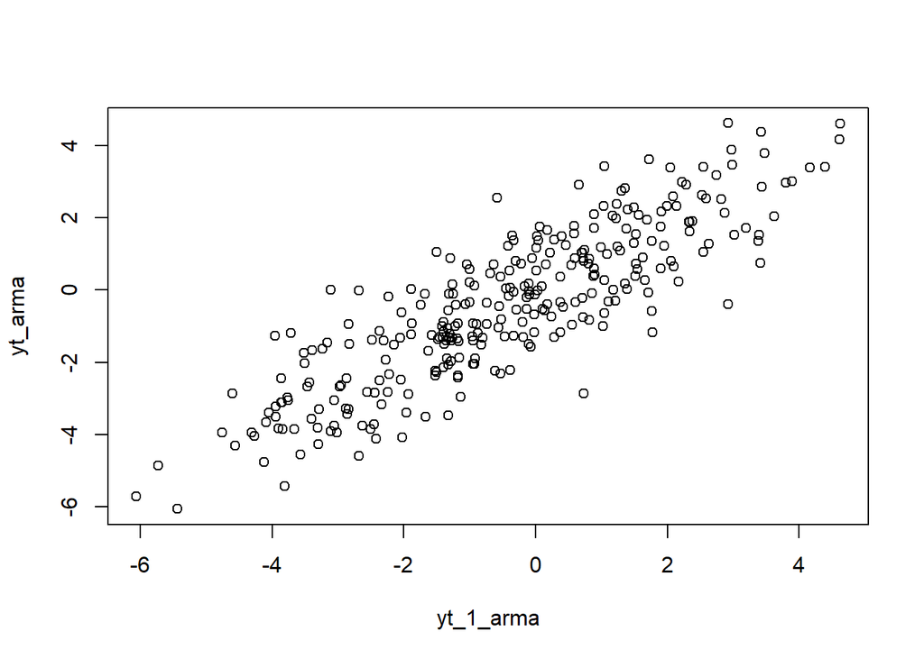

```r
plot(y=yt_arma,x=yt_1_arma)
```

Berdasarkan scatterplot tersebut, terlihat bahwa terdapat hubungan positif antara $Y_t$ dengan $Y_{t-1}$. Hal ini sesuai dengan teori yang ada

```r
cor(yt_arma,yt_1_arma)
```

```
## [1] 0.8575633
```

#### Korelasi antara $Y_t$ dengan $Y_{t-2}$

```r
#Yt
yt_arma2 <- arma11[-c(1,2)]
yt_arma2
```

```
##   [1] -3.231207993 -1.631132959 -1.676981403 -0.105208387 -1.502792365
##   [6]  1.045669906 -0.637188352  0.716165513  0.888735081  0.594204249
##  [11]  0.890311553  2.093218738  0.653495759  2.919425359 -0.395346248
##  [16]  0.550128836 -0.957608831 -1.281497296 -1.393133355 -2.148744265
##  [21] -1.520171748 -2.237414139 -2.822544461 -1.500514978 -2.277391994
##  [26] -1.929146743 -2.874890795 -3.290240250 -3.300639770 -4.266264344
##  [31] -4.049208237 -3.393005373 -1.671216730 -3.502558447 -2.022560989
##  [36] -4.089017462 -3.663083018 -3.859493620 -3.105787264 -3.903234581
##  [41] -3.834464514 -3.847306249 -3.112171825  0.013777764  1.169480232
##  [46]  2.055794736  0.809683713  0.857902234 -0.094236558 -0.129895804
##  [51] -0.199062221 -0.891888227 -0.949182787 -2.049003379 -2.485497768
##  [56] -1.385418484 -1.485032479 -1.357930050 -1.399908656 -1.160888722
##  [61] -1.878115187 -0.920641169 -1.887823685  0.030896947 -0.016461672
##  [66] -1.174653120 -0.925945728 -2.036299652 -0.619638827 -2.235603735
##  [71] -0.189685862 -1.295909058  0.875219504  0.392269240  1.488834385
```

[output cut: 45 more lines]

```r
#Yt-2
yt_2_arma <- arma11[-c(299,300)]
yt_2_arma
```

```
##   [1] -3.015431801 -3.943882443 -3.231207993 -1.631132959 -1.676981403
##   [6] -0.105208387 -1.502792365  1.045669906 -0.637188352  0.716165513
##  [11]  0.888735081  0.594204249  0.890311553  2.093218738  0.653495759
##  [16]  2.919425359 -0.395346248  0.550128836 -0.957608831 -1.281497296
##  [21] -1.393133355 -2.148744265 -1.520171748 -2.237414139 -2.822544461
##  [26] -1.500514978 -2.277391994 -1.929146743 -2.874890795 -3.290240250
##  [31] -3.300639770 -4.266264344 -4.049208237 -3.393005373 -1.671216730
##  [36] -3.502558447 -2.022560989 -4.089017462 -3.663083018 -3.859493620
##  [41] -3.105787264 -3.903234581 -3.834464514 -3.847306249 -3.112171825
##  [46]  0.013777764  1.169480232  2.055794736  0.809683713  0.857902234
##  [51] -0.094236558 -0.129895804 -0.199062221 -0.891888227 -0.949182787
##  [56] -2.049003379 -2.485497768 -1.385418484 -1.485032479 -1.357930050
##  [61] -1.399908656 -1.160888722 -1.878115187 -0.920641169 -1.887823685
##  [66]  0.030896947 -0.016461672 -1.174653120 -0.925945728 -2.036299652
##  [71] -0.619638827 -2.235603735 -0.189685862 -1.295909058  0.875219504
```

[output cut: 45 more lines]

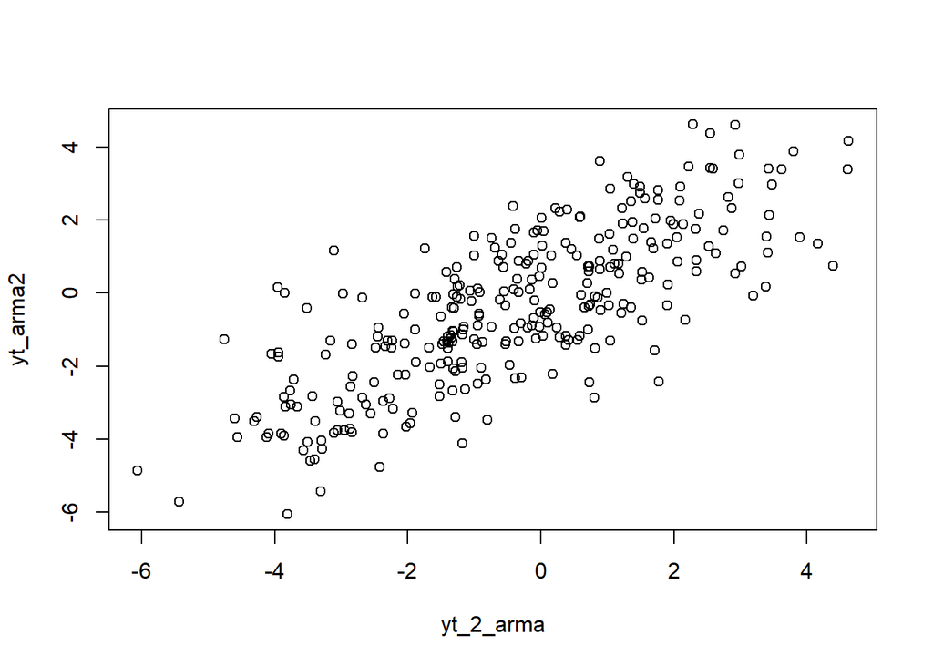

```r
plot(y=yt_arma2,x=yt_2_arma)
```

Berdasarkan scatterplot tersebut, terlihat bahwa terdapat hubungan positif antara Yt dengan Yt−2. Hal ini sesuai dengan teori yang ada

```r
cor(yt_arma2,yt_2_arma)
```

```
## [1] 0.7680965
```

#### Korelasi antara $Y_t$ dengan $Y_{t-3}$

```r
#Yt
yt_arma3 <- arma11[-c(1,2,3)]
yt_arma3
```

```
##   [1] -1.631132959 -1.676981403 -0.105208387 -1.502792365  1.045669906
##   [6] -0.637188352  0.716165513  0.888735081  0.594204249  0.890311553
##  [11]  2.093218738  0.653495759  2.919425359 -0.395346248  0.550128836
##  [16] -0.957608831 -1.281497296 -1.393133355 -2.148744265 -1.520171748
##  [21] -2.237414139 -2.822544461 -1.500514978 -2.277391994 -1.929146743
##  [26] -2.874890795 -3.290240250 -3.300639770 -4.266264344 -4.049208237
##  [31] -3.393005373 -1.671216730 -3.502558447 -2.022560989 -4.089017462
##  [36] -3.663083018 -3.859493620 -3.105787264 -3.903234581 -3.834464514
##  [41] -3.847306249 -3.112171825  0.013777764  1.169480232  2.055794736
##  [46]  0.809683713  0.857902234 -0.094236558 -0.129895804 -0.199062221
##  [51] -0.891888227 -0.949182787 -2.049003379 -2.485497768 -1.385418484
##  [56] -1.485032479 -1.357930050 -1.399908656 -1.160888722 -1.878115187
##  [61] -0.920641169 -1.887823685  0.030896947 -0.016461672 -1.174653120
##  [66] -0.925945728 -2.036299652 -0.619638827 -2.235603735 -0.189685862
##  [71] -1.295909058  0.875219504  0.392269240  1.488834385  2.285515035
```

[output cut: 45 more lines]

```r
#Yt-3
yt_3_arma <- arma11[-c(298,299,300)]
yt_3_arma
```

```
##   [1] -3.015431801 -3.943882443 -3.231207993 -1.631132959 -1.676981403
##   [6] -0.105208387 -1.502792365  1.045669906 -0.637188352  0.716165513
##  [11]  0.888735081  0.594204249  0.890311553  2.093218738  0.653495759
##  [16]  2.919425359 -0.395346248  0.550128836 -0.957608831 -1.281497296
##  [21] -1.393133355 -2.148744265 -1.520171748 -2.237414139 -2.822544461
##  [26] -1.500514978 -2.277391994 -1.929146743 -2.874890795 -3.290240250
##  [31] -3.300639770 -4.266264344 -4.049208237 -3.393005373 -1.671216730
##  [36] -3.502558447 -2.022560989 -4.089017462 -3.663083018 -3.859493620
##  [41] -3.105787264 -3.903234581 -3.834464514 -3.847306249 -3.112171825
##  [46]  0.013777764  1.169480232  2.055794736  0.809683713  0.857902234
##  [51] -0.094236558 -0.129895804 -0.199062221 -0.891888227 -0.949182787
##  [56] -2.049003379 -2.485497768 -1.385418484 -1.485032479 -1.357930050
##  [61] -1.399908656 -1.160888722 -1.878115187 -0.920641169 -1.887823685
##  [66]  0.030896947 -0.016461672 -1.174653120 -0.925945728 -2.036299652
##  [71] -0.619638827 -2.235603735 -0.189685862 -1.295909058  0.875219504
```

[output cut: 45 more lines]

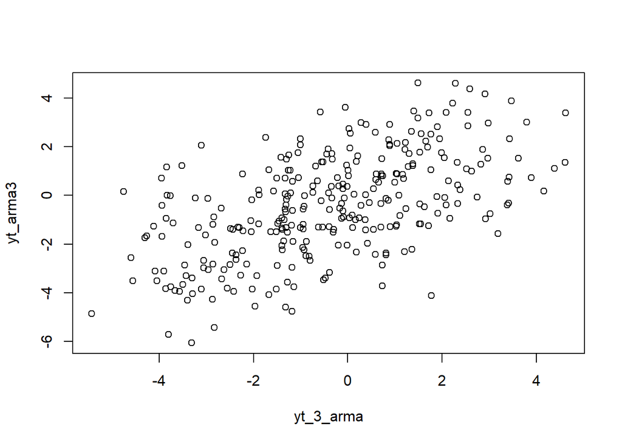

```r
plot(y=yt_arma3,x=yt_3_arma)
```

Berdasarkan scatterplot tersebut, terlihat bahwa terdapat hubungan positif antara
$$Y_t$$
dengan
$$Y_t-3$$
. Hal ini sesuai dengan teori yang ada

```r
cor(yt_arma3,yt_3_arma)
```

```
## [1] 0.5669701
```